# Simulation from a user-specified, ODE-based PK model

### User-defined PK functions using the tci package

The `tci` package provides closed-form solutions for 1-, 2-, 3-, and 3-compartment with effect-site PK models based on solutions described and code provided in Abuhelwa, Foster, and Upton (2015). It does not, however, include an ordinary differential equation (ODE) solver as many other R packages do, including [mrgsolve](https://mrgsolve.github.io/), PKPDsim, and RxODE. `tci` package functions can nonetheless be applied to models from these packages through the creation of user-defined PK functions.

User-defined PK functions should be created to return concentrations at a vector of time points under a continuous infusion and should be assigned S3 class “pkmod.” To illustrate, we create an example two-compartment model based on ODEs is illustrated using the `mrgsolve` R package(Baron 2020). Using `mrgsolve` syntax, a model can be specified as a character string and compiled using the `mcode` function.

```r
library(tci)
library(mrgsolve)
# define two-compartment model based on ODEs
code <- '
$PARAM CL=10, V=10, Q = 10, V2=10
$CMT A1 A2
$ODE
dxdt_A1 = -(CL/V)*A1 - (Q/V)*A1 + (Q/V2)*A2;
dxdt_A2 = -(Q/V2)*A2 + (Q/V)*A1;
'
mod2cpt <- mcode("example", code)
```

```
#> Building example ...
#> done.
```

Initial parameter values are required by `mrgsolve` but can be updated as needed using the `mrgsolve::update` function. We now need to write a wrapper that takes as arguments a time at which to evaluate the PK model (`tm`), an infusion rate (`kR`), PK model parameters (`pars`), initial concentrations (`init`), and an infusion starting time (`inittm`). The starting time is used by functions in `tci` that iteratively calculate concentrations from a series of infusions. The function should return a matrix with concentrations for each compartment in the rows and evaluation times as columns.

```r
# wrapper function to evaluate pk2 in format used by tci
pkmod2cpt_ode <- function(tm, kR, pars,
                          pkm = pk2,
                          init = c(0,0),
                          inittm = 0){

  # begin times at 0 and end at last time evaluated
  tm <- tm - inittm
  end_inf <- max(tm)

  # name parameter/initial concentrations
  names(pars) <- toupper(names(pars))
  names(init) <- c("A1","A2")

  # pass parameters as list
  pars <- sapply(pars, as.list)
  vols <- unlist(pars[c("V","V2")])

  # update parameters and initial values (as amounts)
  mod2cpt <- update(mod2cpt, param = pars, init = init*vols)

  # dosing regimen - mrgsolve function in terms of amount infused
  event <- ev(amt =  kR*end_inf, time = 0, tinf = end_inf)

  # simulate responses (skip tm=0 unless specified)
  dat <- mrgsim_q(x = mod2cpt, # pk model
                  data = event, # dosing event
                  stime = tm) # evaluation times

  # skip tm=0 unless specified in tm
  dat <- dat@data[-1,]

  # return concentrations with compartments in rows and times in columns
  cons <- t(dat[,c("A1","A2")]) / vols

  rownames(cons) <- colnames(cons) <- NULL
  return(cons)
}
class(pkmod2cpt_ode) <- "pkmod"
```

For use with the `tci` package, the user-defined PK function should have class “pkmod.” We can now assign parameter values and predict from this model as we would any other.

```r
# create dose
dose <- create_intvl(
  as.matrix(cbind(time = c(0.5,4,4.5,10),
                  infrt = c(100,0,100,0)))
)

# model parameters
pars_2cpt <- c(CL = 15, V = 10, Q = 10, V2 = 20)

# predict concentrations
predict_pkmod(pkmod2cpt_ode,
              pars = pars_2cpt,
              inf = dose,
              tms = c(1,2,3))
```

```
#>      time        c1        c2
#> [1,]    1 1.0084483 0.6881986
#> [2,]    2 0.3252449 0.6216142
#> [3,]    3 0.2181003 0.4785318
```

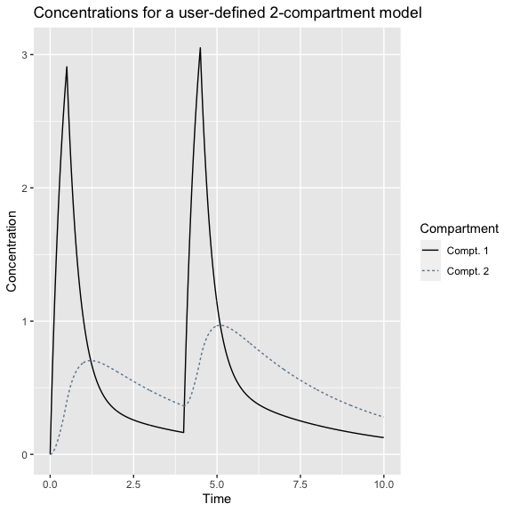

```r
# plot concentrations
plot(pkmod2cpt_ode,
     pars = pars_2cpt,
     inf = dose,
     title = "Concentrations for a user-defined 2-compartment model")
```

We can also apply TCI algorithms to calculate infusion schedules required to reach designated targets with the user-defined model.

```r
# target concentration = 1 for times 0 - 5
# target concentration = 2 for times 5 - 10
tci_times <- c(0,5,10)
tci_targets <- c(1,2,2)

# plasma-targeting
inf_3cpt_plasma <- tci(Ct = tci_targets,
                       tms = tci_times,
                       pkmod = pkmod2cpt_ode,
                       pars = pars_2cpt,
                       tci_alg = "plasma")
# print infusion schedule
head(inf_3cpt_plasma)
```

```
#>         infrt     begin       end       dtm Ct c1_start   c2_start c1_end
#> [1,] 73.20009 0.0000000 0.1666667 0.1666667  1        0 0.00000000      1
#> [2,] 24.15371 0.1666667 0.3333333 0.1666667  1        1 0.04324996      1
#> [3,] 23.42262 0.3333333 0.5000000 0.1666667  1        1 0.11966300      1
#> [4,] 22.74993 0.5000000 0.6666667 0.1666667  1        1 0.18997314      1
#> [5,] 22.13097 0.6666667 0.8333333 0.1666667  1        1 0.25466780      1
#> [6,] 21.56144 0.8333333 1.0000000 0.1666667  1        1 0.31419547      1
#>          c2_end
#> [1,] 0.04324996
#> [2,] 0.11966300
#> [3,] 0.18997314
#> [4,] 0.25466780
#> [5,] 0.31419547
#> [6,] 0.36896883
```

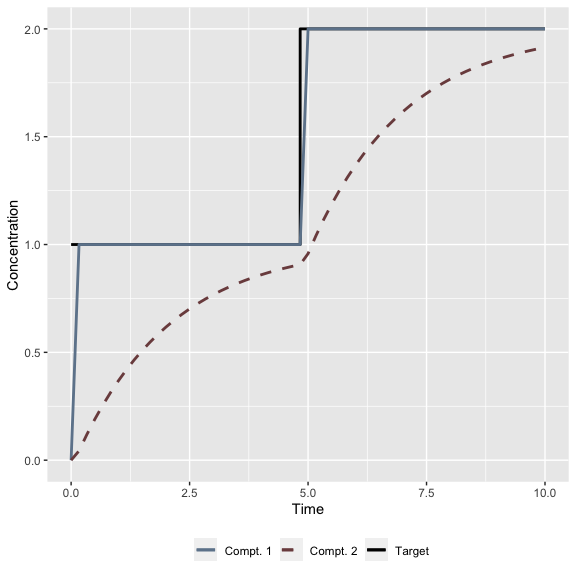

```r
# plot infusion schedule
plot(inf_3cpt_plasma)
```

### References

Abuhelwa, Ahmad Y., David J R Foster, and Richard N. Upton. 2015. “ADVAN-style analytical solutions for common pharmacokinetic models.” *Journal of Pharmacological and Toxicological Methods* 73: 42–48. https://doi.org/10.1016/j.vascn.2015.03.004.

Baron, Kyle T. 2020. *Mrgsolve: Simulate from ODE-Based Models*. https://CRAN.R-project.org/package=mrgsolve.